# EDF 6938 Lecture 6: Binary Prediction Methods (I)

A.C. Thomas – FSSS

10/04/2015

One of the biggest reasons for the large presence of computer science’s foray into “machine learning” – what statisticians would have just called “statistics” for decades – is the field’s success in answering questions of prediction, particularly with to binary outcomes.

Today we’ll cover the most straightforward “statistical learning” method for prediction, and follow it with other binary prediction methods that are more common in industry next week.

## 1. Binary Regression with `glm()`

The options here are essentially the same as they were in the linear case: outcomes given predictors. For this example, let’s use a data set with a well-understood variable set: a passenger roster for the RMS Titanic.

```r
library(dplyr)
titanic <- read.table ("http://www.acthomas.ca/FSSS/data/titanic.txt", header=TRUE)
head(titanic)
```

```
##   Class Adult Male Survived
## 1     1     1    1        1
## 2     1     1    1        1
## 3     1     1    1        1
## 4     1     1    1        1
## 5     1     1    1        1
## 6     1     1    1        1
```

```r
summary(titanic)
```

```
##      Class           Adult             Male           Survived
##  Min.   :0.000   Min.   :0.0000   Min.   :0.0000   Min.   :0.000
##  1st Qu.:0.000   1st Qu.:1.0000   1st Qu.:1.0000   1st Qu.:0.000
##  Median :1.000   Median :1.0000   Median :1.0000   Median :0.000
##  Mean   :1.369   Mean   :0.9505   Mean   :0.7865   Mean   :0.323
##  3rd Qu.:3.000   3rd Qu.:1.0000   3rd Qu.:1.0000   3rd Qu.:1.000
##  Max.   :3.000   Max.   :1.0000   Max.   :1.0000   Max.   :1.000
```

We need one adjustment.

```r
titanic <- mutate (titanic,
                   Class = c("Crew","First","Second","Third")[Class + 1])
```

Let’s find the total ship’s complement divided by each factor:

```r
group_by (titanic, Adult) %>% summarize (count=n(), Survived = sum(Survived))
```

```
## Source: local data frame [2 x 3]
##
##   Adult count Survived
##   (int) (int)    (int)
## 1     0   109       57
## 2     1  2092      654
```

```r
group_by (titanic, Class, Male, Adult) %>% summarize (count=n(), Survived = sum(Survived))
```

```
## Source: local data frame [14 x 5]
## Groups: Class, Male [?]
##
##     Class  Male Adult count Survived
##     (chr) (int) (int) (int)    (int)
## 1    Crew     0     1    23       20
## 2    Crew     1     1   862      192
## 3   First     0     0     1        1
## 4   First     0     1   144      140
## 5   First     1     0     5        5
## 6   First     1     1   175       57
## 7  Second     0     0    13       13
## 8  Second     0     1    93       80
## 9  Second     1     0    11       11
## 10 Second     1     1   168       14
## 11  Third     0     0    31       14
## 12  Third     0     1   165       76
## 13  Third     1     0    48       13
## 14  Third     1     1   462       75
```

Let’s now fit a model to survival:

```r
survival.one <- glm (Survived ~ Class - 1, data=titanic)
summary(survival.one)
```

```
##
## Call:
## glm(formula = Survived ~ Class - 1, data = titanic)
##
## Deviance Residuals:
##     Min       1Q   Median       3Q      Max
## -0.6246  -0.2521  -0.2396   0.3754   0.7604
##
## Coefficients:
##             Estimate Std. Error t value Pr(>|t|)
## ClassCrew    0.23955    0.01504   15.93   <2e-16 ***
## ClassFirst   0.62462    0.02481   25.17   <2e-16 ***
## ClassSecond  0.41404    0.02650   15.62   <2e-16 ***
## ClassThird   0.25212    0.01684   14.97   <2e-16 ***
## ---
## Signif. codes:  0 '***' 0.001 '**' 0.01 '*' 0.05 '.' 0.1 ' ' 1
##
## (Dispersion parameter for gaussian family taken to be 0.2001295)
##
##     Null deviance: 711.00  on 2201  degrees of freedom
## Residual deviance: 439.68  on 2197  degrees of freedom
## AIC: 2711.2
##
## Number of Fisher Scoring iterations: 2
```

Well, this would be good if we were directly fitting to the share of survivors – as if this was a straight linear model on the zero-one outcomes. (Not a problem here, but would be with more variables.) We need better!

Logistic link is default:

```r
survival.logit <- glm (Survived ~ Class - 1, family=binomial, data=titanic)
summary(survival.logit)
```

```
##
## Call:
## glm(formula = Survived ~ Class - 1, family = binomial, data = titanic)
##
## Deviance Residuals:
##     Min       1Q   Median       3Q      Max
## -1.3999  -0.7623  -0.7401   0.9702   1.6906
##
## Coefficients:
##             Estimate Std. Error z value Pr(>|z|)
## ClassCrew   -1.15516    0.07876 -14.667  < 2e-16 ***
## ClassFirst   0.50918    0.11455   4.445 8.79e-06 ***
## ClassSecond -0.34731    0.12026  -2.888  0.00388 **
## ClassThird  -1.08731    0.08667 -12.545  < 2e-16 ***
## ---
## Signif. codes:  0 '***' 0.001 '**' 0.01 '*' 0.05 '.' 0.1 ' ' 1
##
## (Dispersion parameter for binomial family taken to be 1)
##
##     Null deviance: 3051.2  on 2201  degrees of freedom
## Residual deviance: 2588.6  on 2197  degrees of freedom
## AIC: 2596.6
##
## Number of Fisher Scoring iterations: 4
```

“Probit” link is also possible:

```r
survival.probit <- glm (Survived ~ Class - 1, family=binomial(link=probit), data=titanic)
summary(survival.probit)
```

```
##
## Call:
## glm(formula = Survived ~ Class - 1, family = binomial(link = probit),
##     data = titanic)
##
## Deviance Residuals:
##     Min       1Q   Median       3Q      Max
## -1.3999  -0.7623  -0.7401   0.9702   1.6906
##
## Coefficients:
##             Estimate Std. Error z value Pr(>|z|)
## ClassCrew   -0.70776    0.04620 -15.320  < 2e-16 ***
## ClassFirst   0.31763    0.07081   4.486 7.27e-06 ***
## ClassSecond -0.21718    0.07488  -2.900  0.00373 **
## ClassThird  -0.66782    0.05120 -13.044  < 2e-16 ***
## ---
## Signif. codes:  0 '***' 0.001 '**' 0.01 '*' 0.05 '.' 0.1 ' ' 1
##
## (Dispersion parameter for binomial family taken to be 1)
##
##     Null deviance: 3051.2  on 2201  degrees of freedom
## Residual deviance: 2588.6  on 2197  degrees of freedom
## AIC: 2596.6
##
## Number of Fisher Scoring iterations: 4
```

The effective difference between the two is in the link function, but at practical levels they’re basically capturing the same things:

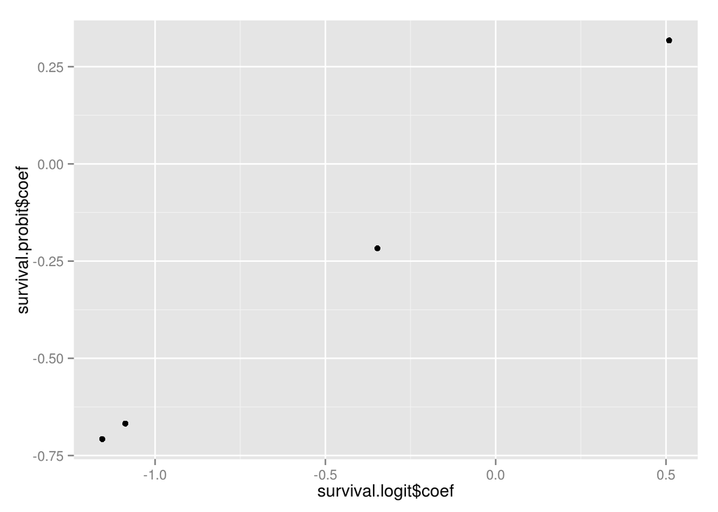

```r
library(ggplot2)
qplot (survival.logit$coef, survival.probit$coef)
```

```r
cbind (survival.logit$coef, survival.probit$coef, survival.logit$coef/survival.probit$coef)
```

```
##                   [,1]       [,2]     [,3]
## ClassCrew   -1.1551591 -0.7077572 1.632140
## ClassFirst   0.5091849  0.3176252 1.603100
## ClassSecond -0.3473092 -0.2171773 1.599197
## ClassThird  -1.0873127 -0.6678188 1.628155
```

See here:

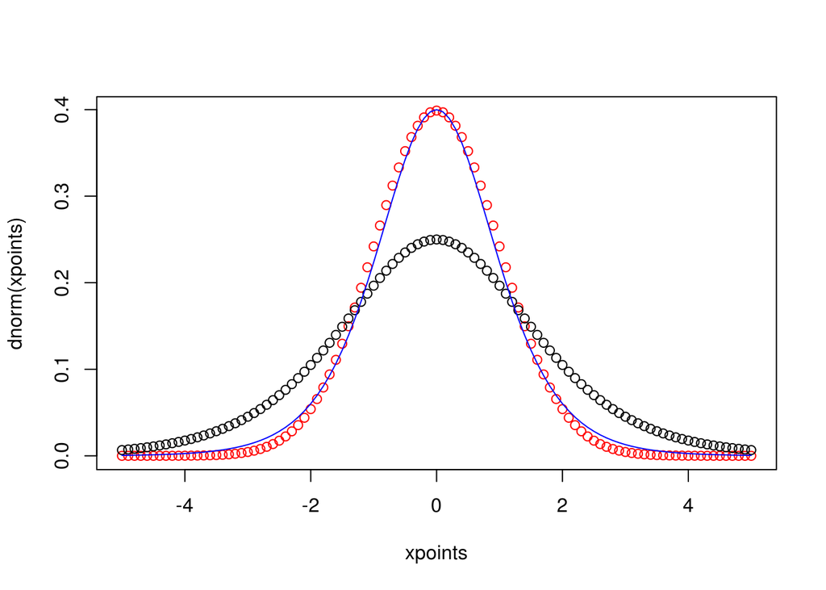

```r
xpoints <- seq(-5,5,by=0.1)
plot (xpoints, dnorm(xpoints), col=2)
points (xpoints, dlogis(xpoints))
lines (xpoints, dlogis(xpoints, scale=0.25/0.4), col=4)
```

The main difference is in the tails of the distribution, but for our purposes they’re just about the same. So let’s continue with logit for now.

```r
survival.more <- glm (Survived ~ Male + Class + Adult, family=binomial, data=titanic)
summary(survival.more)
```

```
##
## Call:
## glm(formula = Survived ~ Male + Class + Adult, family = binomial,
##     data = titanic)
##
## Deviance Residuals:
##     Min       1Q   Median       3Q      Max
## -2.0812  -0.7149  -0.6656   0.6858   2.1278
##
## Coefficients:
##             Estimate Std. Error z value Pr(>|z|)
## (Intercept)   2.2477     0.2988   7.522 5.40e-14 ***
## Male         -2.4201     0.1404 -17.236  < 2e-16 ***
## ClassFirst    0.8577     0.1573   5.451 5.00e-08 ***
## ClassSecond  -0.1604     0.1738  -0.923    0.356
## ClassThird   -0.9201     0.1486  -6.192 5.93e-10 ***
## Adult        -1.0615     0.2440  -4.350 1.36e-05 ***
## ---
## Signif. codes:  0 '***' 0.001 '**' 0.01 '*' 0.05 '.' 0.1 ' ' 1
##
## (Dispersion parameter for binomial family taken to be 1)
##
##     Null deviance: 2769.5  on 2200  degrees of freedom
## Residual deviance: 2210.1  on 2195  degrees of freedom
## AIC: 2222.1
##
## Number of Fisher Scoring iterations: 4
```

Here we can be fairly exhaustive: let’s get all combinations of variables.

```r
survival.big <- glm (Survived ~ Male*Class*Adult - 1, family=binomial, data=titanic)
summary(survival.big)
```

```
##
## Call:
## glm(formula = Survived ~ Male * Class * Adult - 1, family = binomial,
##     data = titanic)
##
## Deviance Residuals:
##     Min       1Q   Median       3Q      Max
## -2.6771  -0.7099  -0.5952   0.2374   2.2293
##
## Coefficients: (2 not defined because of singularities)
##                          Estimate Std. Error z value Pr(>|z|)
## Male                     -2.46011    0.81614  -3.014  0.00258 **
## ClassCrew                 1.86087    0.73347   2.537  0.01118 *
## ClassFirst               15.56607 1455.39746   0.011  0.99147
## ClassSecond              15.56607  403.65466   0.039  0.96924
## ClassThird               -0.19416    0.36090  -0.538  0.59060
## Adult                     0.03625    0.39325   0.092  0.92655
## Male:ClassFirst           2.46011 1594.30827   0.002  0.99877
## Male:ClassSecond          2.46011  596.23799   0.004  0.99671
## Male:ClassThird           1.66387    0.65601   2.536  0.01120 *
## Male:Adult               -0.68679    0.52541  -1.307  0.19116
## ClassFirst:Adult        -12.04697 1455.39760  -0.008  0.99340
## ClassSecond:Adult       -13.78524  403.65496  -0.034  0.97276
## ClassThird:Adult               NA         NA      NA       NA
## Male:ClassFirst:Adult    -3.59619 1594.30823  -0.002  0.99820
## Male:ClassSecond:Adult   -3.52818  596.23781  -0.006  0.99528
## Male:ClassThird:Adult          NA         NA      NA       NA
## ---
## Signif. codes:  0 '***' 0.001 '**' 0.01 '*' 0.05 '.' 0.1 ' ' 1
##
## (Dispersion parameter for binomial family taken to be 1)
##
##     Null deviance: 3051.2  on 2201  degrees of freedom
## Residual deviance: 2097.5  on 2187  degrees of freedom
## AIC: 2125.5
##
## Number of Fisher Scoring iterations: 14
```

We have a lot going on here. Let’s reduce it to just adult passengers.

```r
titanic.adult <- filter(titanic, Class != "Crew", Adult == 1)
survival.big.two <- glm (Survived ~ Male*Class, family=binomial, data=titanic.adult)
summary(survival.big.two)
```

```
##
## Call:
## glm(formula = Survived ~ Male * Class, family = binomial, data = titanic.adult)
##
## Deviance Residuals:
##     Min       1Q   Median       3Q      Max
## -2.6771  -0.5952  -0.5952   0.3931   2.2293
##
## Coefficients:
##                  Estimate Std. Error z value Pr(>|z|)
## (Intercept)       3.55535    0.50709   7.011 2.36e-12 ***
## Male             -4.28298    0.53213  -8.049 8.36e-16 ***
## ClassSecond      -1.73827    0.58870  -2.953  0.00315 **
## ClassThird       -3.71325    0.53060  -6.998 2.59e-12 ***
## Male:ClassSecond  0.06801    0.67120   0.101  0.91929
## Male:ClassThird   2.79995    0.56874   4.923 8.52e-07 ***
## ---
## Signif. codes:  0 '***' 0.001 '**' 0.01 '*' 0.05 '.' 0.1 ' ' 1
##
## (Dispersion parameter for binomial family taken to be 1)
##
##     Null deviance: 1585.8  on 1206  degrees of freedom
## Residual deviance: 1066.6  on 1201  degrees of freedom
## AIC: 1078.6
##
## Number of Fisher Scoring iterations: 6
```

## 2. Binary Regression with `glmnet()`

We have the same powerful tools as before to do binary regression. The Titanic data set isn’t big enough to do anything interesting with it (and we don’t expect the same thing to happen again)

For this example, let’s bring in another data set of interest which *does* have out-of-sample validity: the measurements of radon in houses across the state of Minnesota. (Compliments of Gelman and Hill, “Data Analysis…”)

```r
radon <- read.table ("http://www.acthomas.ca/FSSS/data/mn-radon.txt", header=TRUE)
head(radon)
```

```
##   radon log.radon floor          county.name county  uranium log.uranium
## 1   2.2 0.7884574     1 AITKIN                    1 0.502054  -0.6890476
## 2   2.2 0.7884574     0 AITKIN                    1 0.502054  -0.6890476
## 3   2.9 1.0647107     0 AITKIN                    1 0.502054  -0.6890476
## 4   1.0 0.0000000     0 AITKIN                    1 0.502054  -0.6890476
## 5   3.1 1.1314021     0 ANOKA                     2 0.428565  -0.8473129
## 6   2.5 0.9162907     0 ANOKA                     2 0.428565  -0.8473129
```

```r
summary(radon)
```

```
##      radon          log.radon           floor
##  Min.   : 0.000   Min.   :-2.3026   Min.   :0.0000
##  1st Qu.: 1.900   1st Qu.: 0.6419   1st Qu.:0.0000
##  Median : 3.600   Median : 1.2809   Median :0.0000
##  Mean   : 4.768   Mean   : 1.2246   Mean   :0.1665
##  3rd Qu.: 6.000   3rd Qu.: 1.7918   3rd Qu.:0.0000
##  Max.   :48.200   Max.   : 3.8754   Max.   :1.0000
##
##                county.name      county         uranium
##  ST LOUIS            :116   Min.   : 1.00   Min.   :0.4140
##  HENNEPIN            :105   1st Qu.:21.00   1st Qu.:0.6221
##  DAKOTA              : 63   Median :44.00   Median :0.9080
##  ANOKA               : 52   Mean   :43.52   Mean   :0.9339
##  WASHINGTON          : 46   3rd Qu.:70.00   3rd Qu.:1.2011
##  RAMSEY              : 32   Max.   :85.00   Max.   :1.6956
##  (Other)             :505
##   log.uranium
##  Min.   :-0.88183
##  1st Qu.:-0.47467
##  Median :-0.09652
##  Mean   :-0.13171
##  3rd Qu.: 0.18324
##  Max.   : 0.52802
##
```

```
## stat_bin: binwidth defaulted to range/30. Use 'binwidth = x' to adjust this.
```

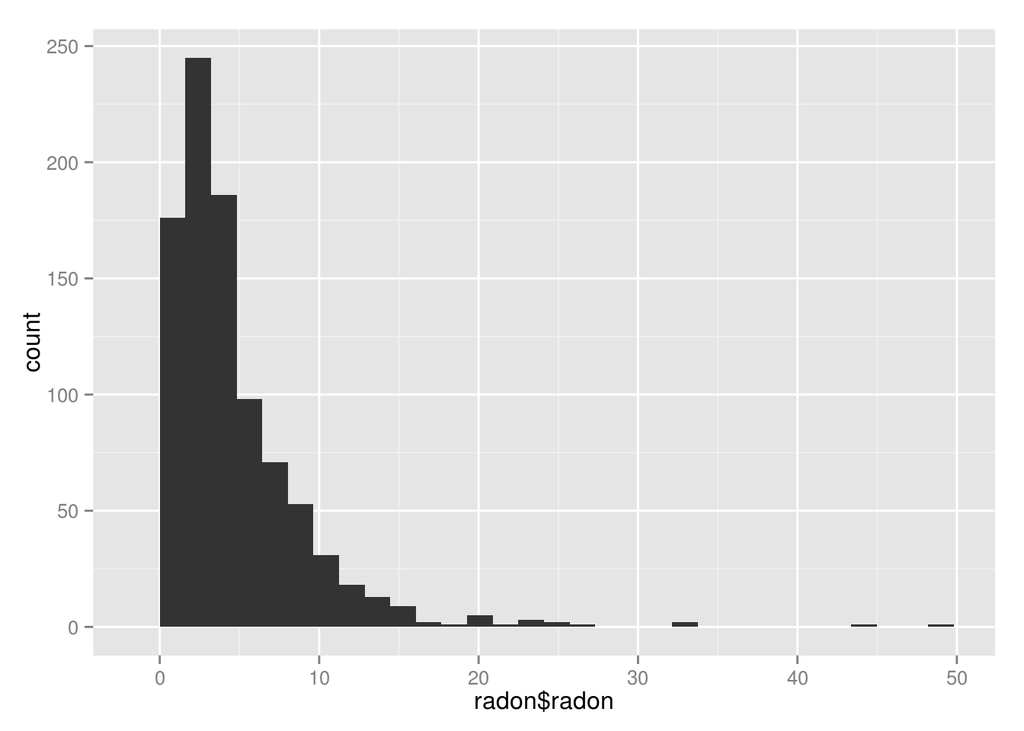

```r
qplot(radon$radon)
```

```
## stat_bin: binwidth defaulted to range/30. Use 'binwidth = x' to adjust this.
```

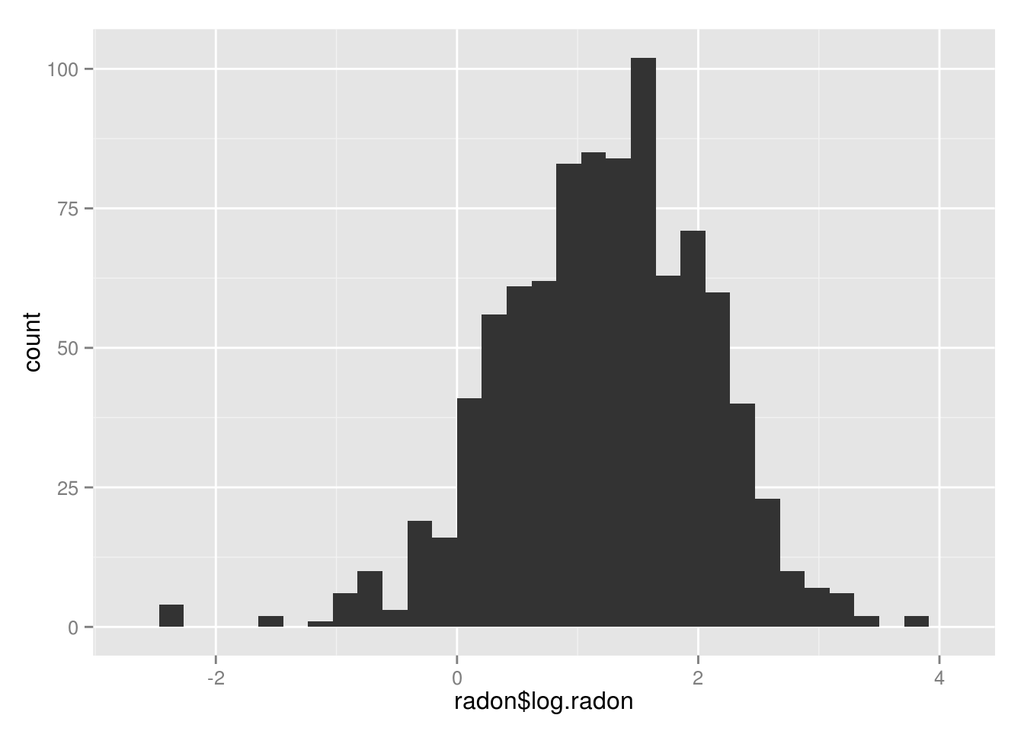

```r
qplot(radon$log.radon)
```

Assume we’re only interested in a “threshold” level of radon for toxicity purposes. (We might think this is ludicrous, but this is actually how policy decisions get made.)

Let’s do the standard `lm()` type first with `log.radon`.

```r
radon.zero <- glm (log.radon ~ log.uranium + floor, data = radon)
summary(radon.zero)
```

```
##
## Call:
## glm(formula = log.radon ~ log.uranium + floor, data = radon)
##
## Deviance Residuals:
##     Min       1Q   Median       3Q      Max
## -3.9676  -0.4809   0.0267   0.4993   2.4297
##
## Coefficients:
##             Estimate Std. Error t value Pr(>|t|)
## (Intercept)  1.43489    0.02953  48.593   <2e-16 ***
## log.uranium  0.78004    0.06982  11.172   <2e-16 ***
## floor       -0.64589    0.06843  -9.438   <2e-16 ***
## ---
## Signif. codes:  0 '***' 0.001 '**' 0.01 '*' 0.05 '.' 0.1 ' ' 1
##
## (Dispersion parameter for gaussian family taken to be 0.596138)
##
##     Null deviance: 668.46  on 918  degrees of freedom
## Residual deviance: 546.06  on 916  degrees of freedom
## AIC: 2137.6
##
## Number of Fisher Scoring iterations: 2
```

Here’s the `glmnet` fit to this data.

```r
library(glmnet)
```

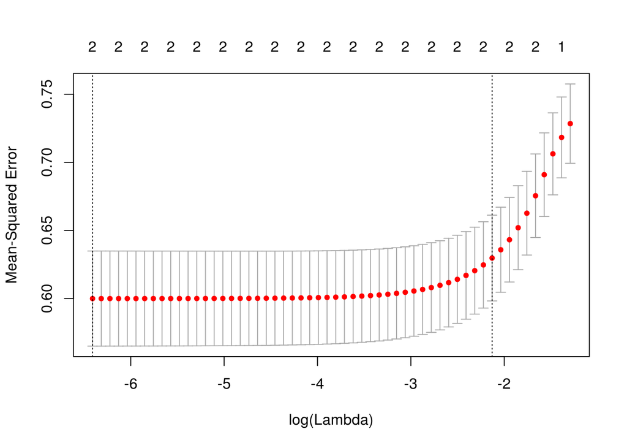

```r
radon.glmnet.cv <- cv.glmnet (cbind(radon$log.uranium, radon$floor), radon$log.radon)
plot(radon.glmnet.cv)
```

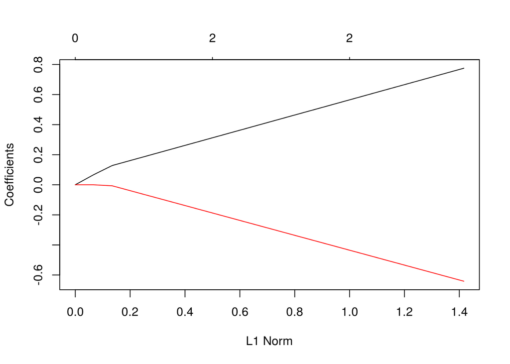

```r
picked.r1 <- which (radon.glmnet.cv$lambda == radon.glmnet.cv$lambda.min)

radon.glmnet <- glmnet (cbind(radon$log.uranium, radon$floor), radon$log.radon)
plot(radon.glmnet)
```

```r
cbind (radon.zero$coefficients, c(radon.glmnet$a0[picked.r1], radon.glmnet$beta[,picked.r1]))
```

```
##                   [,1]       [,2]
## (Intercept)  1.4348911  1.4335027
## log.uranium  0.7800374  0.7753290
## floor       -0.6458853 -0.6412703
```

Now let’s do the standard `glm()` with a binary outcome.

```r
radon <- mutate (radon, badradon = 1*(radon >= 5))
table(radon$badradon)
```

```
##
##   0   1
## 615 304
```

```r
radon.one <- glm (badradon ~ log.uranium, data = radon, family=binomial)
summary(radon.one)
```

```
##
## Call:
## glm(formula = badradon ~ log.uranium, family = binomial, data = radon)
##
## Deviance Residuals:
##     Min       1Q   Median       3Q      Max
## -1.4016  -0.8898  -0.6418   1.1801   2.1531
##
## Coefficients:
##             Estimate Std. Error z value Pr(>|z|)
## (Intercept)  -0.5340     0.0742  -7.197 6.16e-13 ***
## log.uranium   1.9831     0.2268   8.745  < 2e-16 ***
## ---
## Signif. codes:  0 '***' 0.001 '**' 0.01 '*' 0.05 '.' 0.1 ' ' 1
##
## (Dispersion parameter for binomial family taken to be 1)
##
##     Null deviance: 1166.7  on 918  degrees of freedom
## Residual deviance: 1077.6  on 917  degrees of freedom
## AIC: 1081.6
##
## Number of Fisher Scoring iterations: 3
```

```r
radon.two <- glm (badradon ~ log.uranium + floor, data = radon, family=binomial)
summary(radon.two)
```

```
##
## Call:
## glm(formula = badradon ~ log.uranium + floor, family = binomial,
##     data = radon)
##
## Deviance Residuals:
##     Min       1Q   Median       3Q      Max
## -1.5100  -0.9534  -0.5855   1.0956   2.4430
##
## Coefficients:
##             Estimate Std. Error z value Pr(>|z|)
## (Intercept) -0.35081    0.08064  -4.351 1.36e-05 ***
## log.uranium  2.09357    0.23223   9.015  < 2e-16 ***
## floor       -1.25536    0.24060  -5.218 1.81e-07 ***
## ---
## Signif. codes:  0 '***' 0.001 '**' 0.01 '*' 0.05 '.' 0.1 ' ' 1
##
## (Dispersion parameter for binomial family taken to be 1)
##
##     Null deviance: 1166.7  on 918  degrees of freedom
## Residual deviance: 1045.3  on 916  degrees of freedom
## AIC: 1051.3
##
## Number of Fisher Scoring iterations: 4
```

And the `glmnet` version.

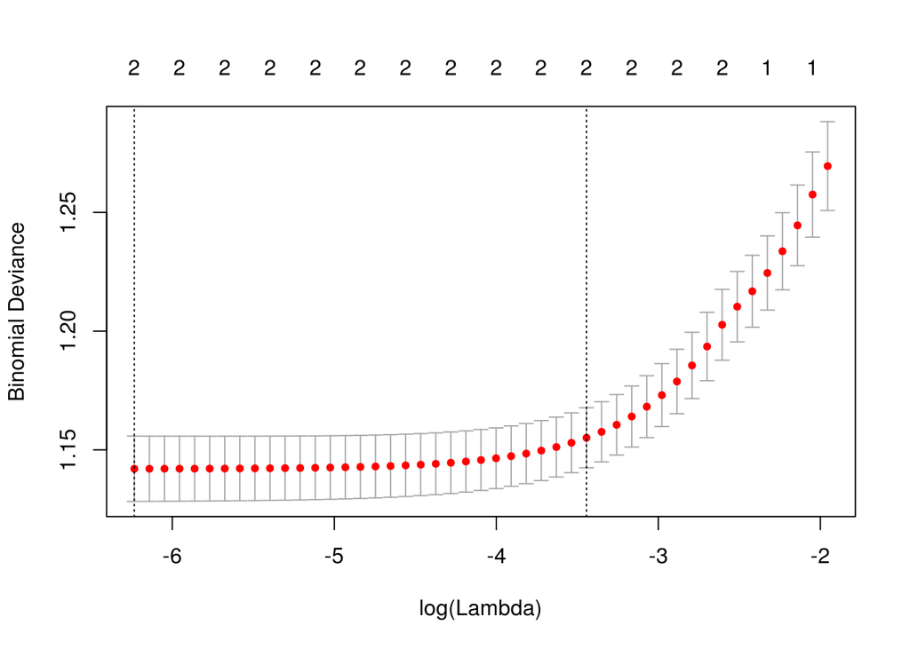

```r
radon.glmnet.cv <- cv.glmnet (cbind(radon$log.uranium, radon$floor), radon$badradon, family="binomial")
plot(radon.glmnet.cv)
```

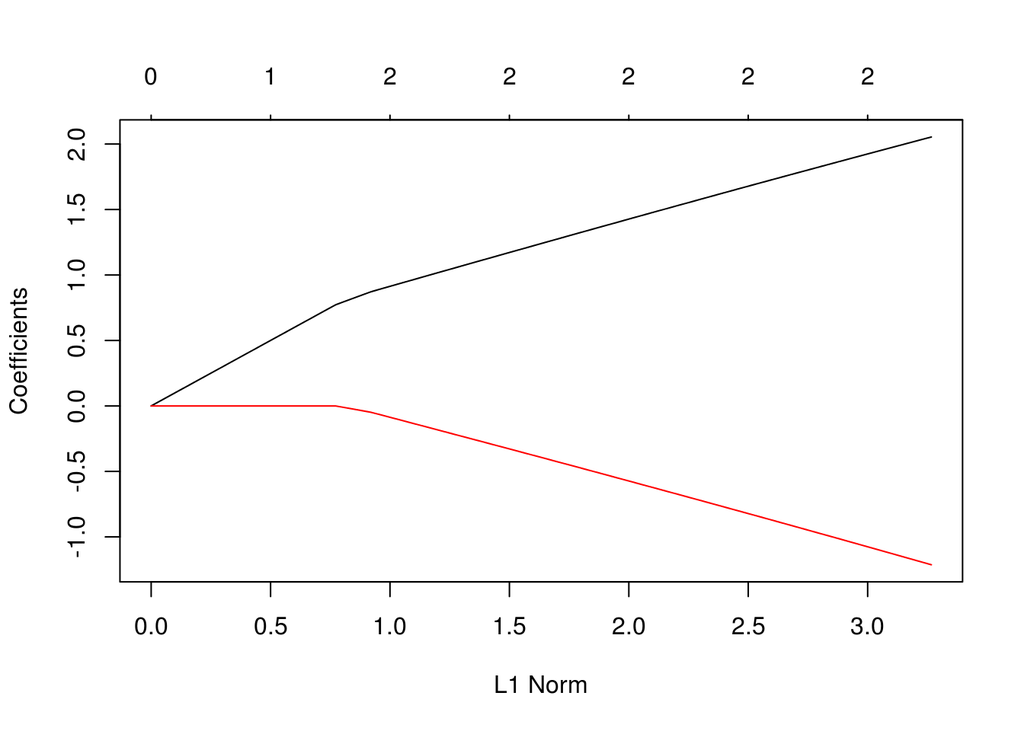

```r
picked.r1 <- which (radon.glmnet.cv$lambda == radon.glmnet.cv$lambda.min)

radon.glmnet <- glmnet (cbind(radon$log.uranium, radon$floor), radon$badradon, family="binomial")
plot(radon.glmnet)
```

```r
cbind (radon.two$coefficients, c(radon.glmnet$a0[picked.r1], radon.glmnet$beta[,picked.r1]))
```

```
##                   [,1]       [,2]
## (Intercept) -0.3508067 -0.3573939
## log.uranium  2.0935724  2.0540051
## floor       -1.2553596 -1.2126913
```

No big deal so far. Let’s add in counties now, since that’s one aspect of the variation we’d love to pick up.

```r
bigradon <- glm (badradon ~ log.uranium + floor + county.name, data = radon, family=binomial)
summary(bigradon)
```

```
##
## Call:
## glm(formula = badradon ~ log.uranium + floor + county.name, family = binomial,
##     data = radon)
##
## Deviance Residuals:
##    Min      1Q  Median      3Q     Max
##  -8.49    0.00    0.00    0.00    8.49
##
## Coefficients: (1 not defined because of singularities)
##                                   Estimate Std. Error    z value Pr(>|z|)
## (Intercept)                     -4.418e+15  3.333e+07 -132555212   <2e-16
## log.uranium                     -2.407e+14  5.567e+07   -4323688   <2e-16
## floor                           -9.217e+14  6.523e+06 -141303819   <2e-16
## county.nameANOKA                 4.181e+15  4.042e+07  103437151   <2e-16
## county.nameBECKER                2.003e+15  4.925e+07   40670419   <2e-16
## county.nameBELTRAMI              5.445e+15  3.995e+07  136288912   <2e-16
## county.nameBENTON                4.614e+15  4.471e+07  103208256   <2e-16
## county.nameBIG STONE             3.010e+15  6.239e+07   48241826   <2e-16
## county.nameBLUE EARTH            4.949e+15  4.728e+07  104679235   <2e-16
## county.nameBROWN                 4.946e+15  5.542e+07   89244527   <2e-16
## county.nameCARLTON               4.430e+15  3.466e+07  127817697   <2e-16
## county.nameCARVER                4.902e+15  4.583e+07  106964238   <2e-16
## county.nameCASS                  4.272e+15  4.330e+07   98654394   <2e-16
## county.nameCHIPPEWA              6.736e+15  5.519e+07  122036684   <2e-16
## county.nameCHISAGO               5.742e+15  4.456e+07  128856450   <2e-16
## county.nameCLAY                  4.121e+15  5.028e+07   81963529   <2e-16
## county.nameCLEARWATER            2.613e+15  4.613e+07   56637969   <2e-16
## county.nameCOOK                 -2.071e+14  5.557e+07   -3726744   <2e-16
## county.nameCOTTONWOOD            4.065e+15  5.774e+07   70400677   <2e-16
## county.nameCROW WING             4.121e+15  3.729e+07  110495081   <2e-16
## county.nameDAKOTA                2.326e+15  3.366e+07   69111468   <2e-16
## county.nameDODGE                 8.985e+15  5.818e+07  154444464   <2e-16
## county.nameDOUGLAS               3.557e+15  4.489e+07   79242681   <2e-16
## county.nameFARIBAULT             3.892e+15  5.249e+07   74155548   <2e-16
## county.nameFILLMORE              4.752e+14  6.916e+07    6871232   <2e-16
## county.nameFREEBORN              4.176e+15  4.735e+07   88210788   <2e-16
## county.nameGOODHUE               5.884e+15  4.436e+07  132643255   <2e-16
## county.nameHENNEPIN              5.178e+15  3.128e+07  165520978   <2e-16
## county.nameHOUSTON               3.345e+15  6.096e+07   54881699   <2e-16
```

[output cut: 141 more lines]

```
## county.nameWATONWAN             ***
## county.nameWILKIN               ***
## county.nameWINONA               ***
## county.nameWRIGHT               ***
## county.nameYELLOW MEDICINE
## ---
## Signif. codes:  0 '***' 0.001 '**' 0.01 '*' 0.05 '.' 0.1 ' ' 1
##
## (Dispersion parameter for binomial family taken to be 1)
##
##     Null deviance:  1166.7  on 918  degrees of freedom
## Residual deviance: 23356.3  on 833  degrees of freedom
## AIC: 23528
##
## Number of Fisher Scoring iterations: 25
```

Yikes! What went wrong here? Complete separation – some counties have no cases (as we can expect).

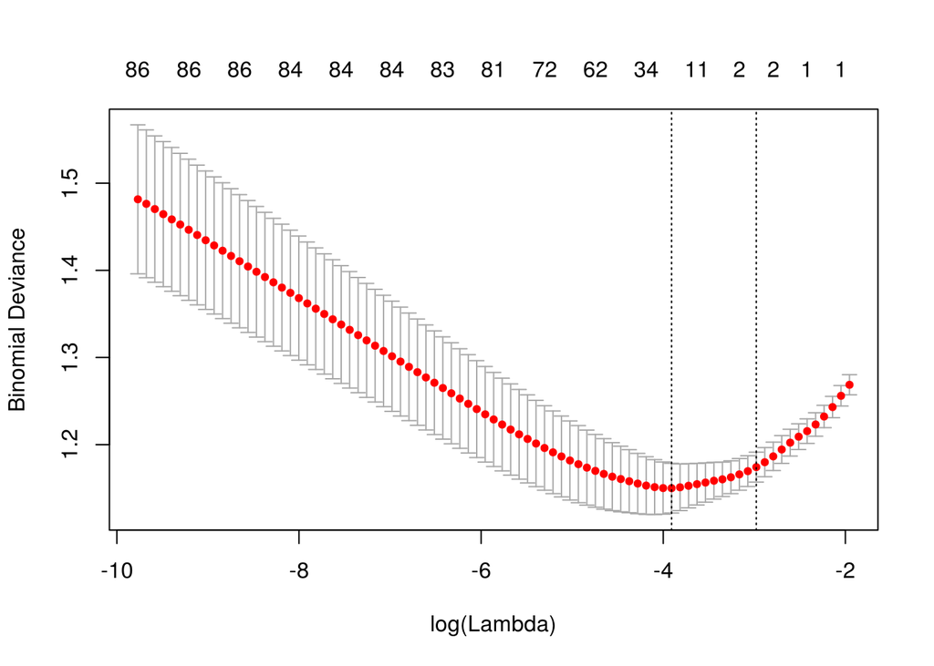

```r
county.break <- model.matrix (~ 0 + county.name, radon)
covmat <- cbind(log.u=radon$log.uranium, floor=radon$floor, county.break)
radon.glmnet.county.cv <- cv.glmnet (covmat, radon$badradon, family="binomial")
plot(radon.glmnet.county.cv)
```

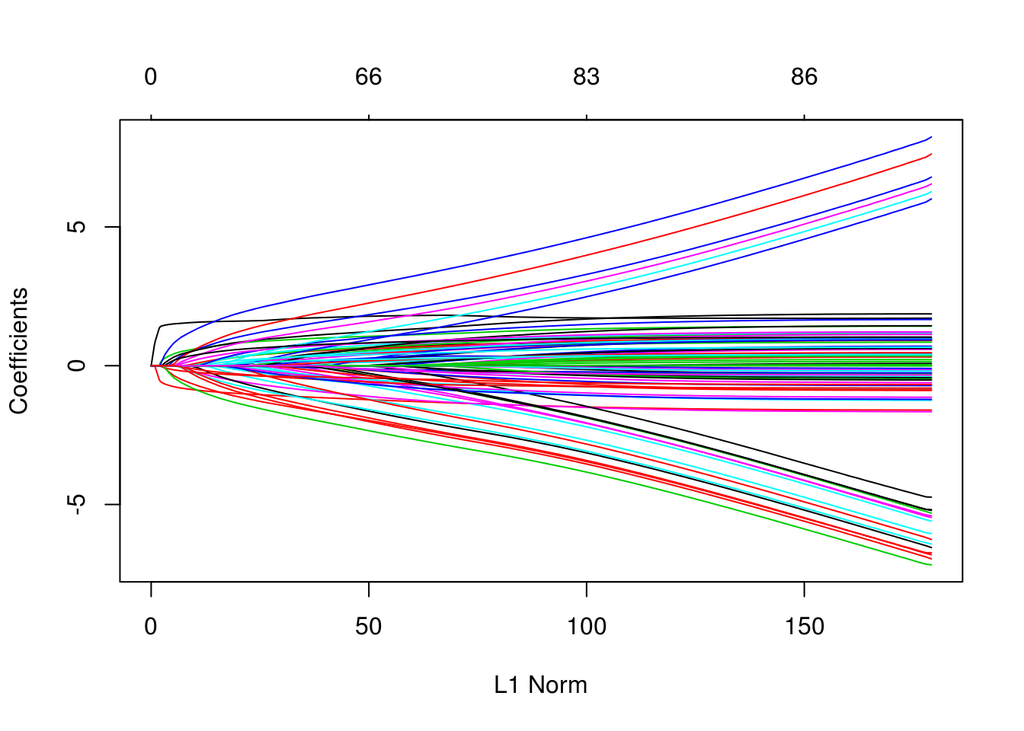

```r
picked.r2 <- which (radon.glmnet.county.cv$lambda == radon.glmnet.county.cv$lambda.min)

radon.glmnet <- glmnet (covmat, radon$badradon, family="binomial")
plot(radon.glmnet)
```

```r
print(radon.glmnet$beta[,picked.r2])
```

```
##                           log.u                           floor
##                     1.570776916                    -0.888401407
## county.nameAITKIN               county.nameANOKA
##                     0.000000000                     0.000000000
## county.nameBECKER               county.nameBELTRAMI
##                     0.000000000                     0.000000000
## county.nameBENTON               county.nameBIG STONE
##                     0.000000000                     0.000000000
## county.nameBLUE EARTH           county.nameBROWN
##                     0.630344209                     0.000000000
## county.nameCARLTON              county.nameCARVER
##                     0.000000000                     0.000000000
## county.nameCASS                 county.nameCHIPPEWA
##                     0.000000000                     0.000000000
## county.nameCHISAGO              county.nameCLAY
##                     0.000000000                     0.000000000
## county.nameCLEARWATER           county.nameCOOK
##                     0.000000000                     0.000000000
## county.nameCOTTONWOOD           county.nameCROW WING
##                     0.000000000                     0.000000000
## county.nameDAKOTA               county.nameDODGE
##                     0.000000000                     0.616140712
## county.nameDOUGLAS              county.nameFARIBAULT
##                     0.000000000                    -0.260782327
## county.nameFILLMORE             county.nameFREEBORN
##                    -0.089652265                     0.109009800
## county.nameGOODHUE              county.nameHENNEPIN
##                     0.000000000                     0.000000000
## county.nameHOUSTON              county.nameHUBBARD
##                     0.000000000                     0.000000000
## county.nameISANTI               county.nameITASCA
##                     0.000000000                     0.000000000
## county.nameJACKSON              county.nameKANABEC
##                     0.043950563                     0.000000000
## county.nameKANDIYOHI            county.nameKITTSON
##                     0.027248982                     0.000000000
## county.nameKOOCHICHING          county.nameLAC QUI PARLE
##                     0.000000000                     0.667192500
## county.nameLAKE                 county.nameLAKE OF THE WOODS
##                     0.000000000                     0.000000000
```

[output cut: 33 more lines]

```
##                     0.000000000                     0.000000000
## county.nameST LOUIS             county.nameSWIFT
##                    -0.247188278                    -0.912125416
## county.nameTODD                 county.nameTRAVERSE
##                     0.000000000                     0.000000000
## county.nameWABASHA              county.nameWADENA
##                     0.240263173                     0.000000000
## county.nameWASECA               county.nameWASHINGTON
##                     0.000000000                     0.000000000
## county.nameWATONWAN             county.nameWILKIN
##                     1.364199629                     0.000000000
## county.nameWINONA               county.nameWRIGHT
##                     0.000000000                     0.409020605
## county.nameYELLOW MEDICINE
##                    -0.426199243
```